# Сравнение бенефитов сотрудников в Индии и Турции

Начнем с обзора количества локаций и числа сотрудников в каждой из стран.

|  | Country | Location | Count |
| --- | --- | --- | --- |
| 1 | India | A1_1 | 671 |
| 2 | Turkey | B1_1 | 35 |

В данных представлено по одной локации из Индии и Турции. **Количество сотрудников в Индии значительно выше — почти в 19 раз**. Перейдём к сравнению общих показателей по локациям.

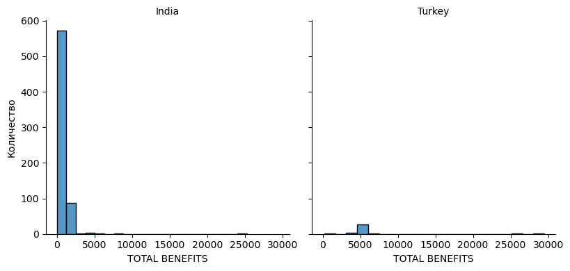

Как видно из графиков, в Индии большинство сотрудников получают небольшие суммы бенефитов, в то время как в Турции основная часть работников получает более высокие выплаты. Также можно заметить, что небольшая группа людей получает значительно больше бенефитов, чем большинство работников. Проверим, имеются ли в данных выраженные статистические выбросы.

|  | Country | Location | Actual position | TOTAL BENEFITS |
| --- | --- | --- | --- | --- |
| 680 | Turkey | B1_1 | HR Director | 29493.029197 |
| 679 | Turkey | B1_1 | Administrative Director | 26174.197080 |
| 651 | India | A1_1 | Manager | 25283.855422 |
| 273 | India | A1_1 | Country Manager | 24607.626506 |
| 270 | India | A1_1 | Air Support Manager | 8559.000000 |
| 678 | Turkey | B1_1 | Accounting & Tax Manager | 7340.328467 |

Как видно из данных, **четыре сотрудника получают значительно больше бенефитов, чем остальные**. Далее значения снижаются постепенно при сортировке от большего к меньшему.

Два из этих сотрудников — экспаты из Индии, что, вероятно, объясняет их высокие бенефиты. Ещё двое — работники из Турции, у которых основная часть бенефитов связана с компенсацией автомобильных расходов.

Рассмотрим сводные таблицы с учётом четырёх статистических выбросов и без них, чтобы сравнить средние значения и стандартную ошибку среднего в обоих случаях.

Все данные

|  | TOTAL BENEFITS |
| --- | --- |
| count | 706.000000 |
| mean | 691.142635 |
| std | 2269.075683 |
| min | 0.000000 |
| 25% | 73.144578 |
| 50% | 73.144578 |
| 75% | 113.180723 |
| max | 29493.029197 |

Без топ-4

|  | TOTAL BENEFITS |
| --- | --- |
| count | 702.000000 |
| mean | 544.712240 |
| std | 1169.665326 |
| min | 0.000000 |
| 25% | 73.144578 |
| 50% | 73.144578 |
| 75% | 113.180723 |
| max | 8559.000000 |

Далее рассмотрим общие затраты по странам, и средние значения на одного сотрудника.

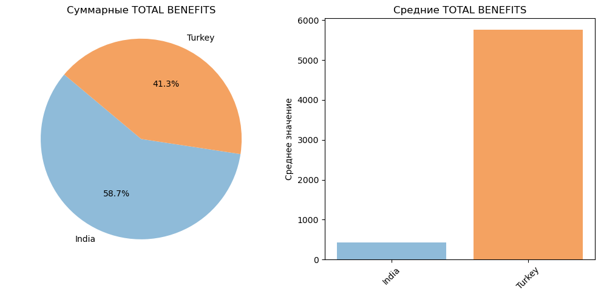

Из-за большого количества сотрудников, совокупные затраты на бенефиты в Индии выше. Однако **в среднем один сотрудник в Турции получает в 13.49 раза больше бенефитов**, чем в Индии. Это может указывать либо на более высокие должности в Турции, либо на существенный дисбаланс в распределении бенефитов между странами. Сравним теперь одни и те же должности в обеих странах. **В Турции представлено 11 позиций, 7 из которых также есть в Индии.**

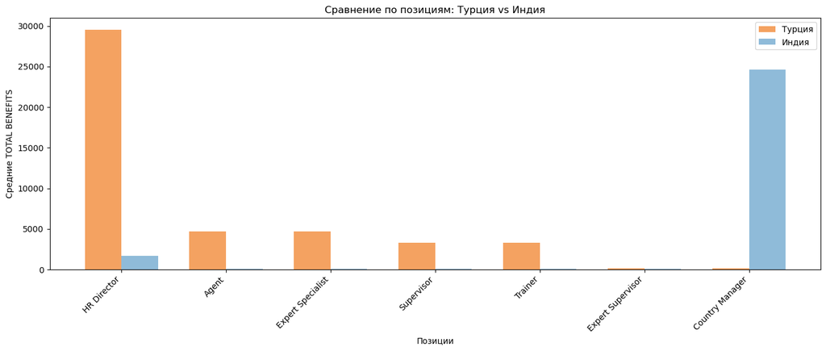

Сравнение демонстрирует заметное смещение в сторону Турции по уровню затрат на бенефиты, за исключением одной позиции — Country Manager. В обеих странах на этой роли работает по одному сотруднику, однако в Индии это экспат, что и объясняет более высокий уровень затрат.  
Такая ситуация указывает на отсутствие унифицированной политики компенсаций между странами и ролями.

Чтобы сделать окончательные выводы, рассмотрим затраты на бенефиты по позициям. В выборке **75 позиций**, относящихся к этим двум странам. Для упрощения визуализации рассмотрим **топ-10 позиций, на которые приходится 71.63% от общих затрат.**

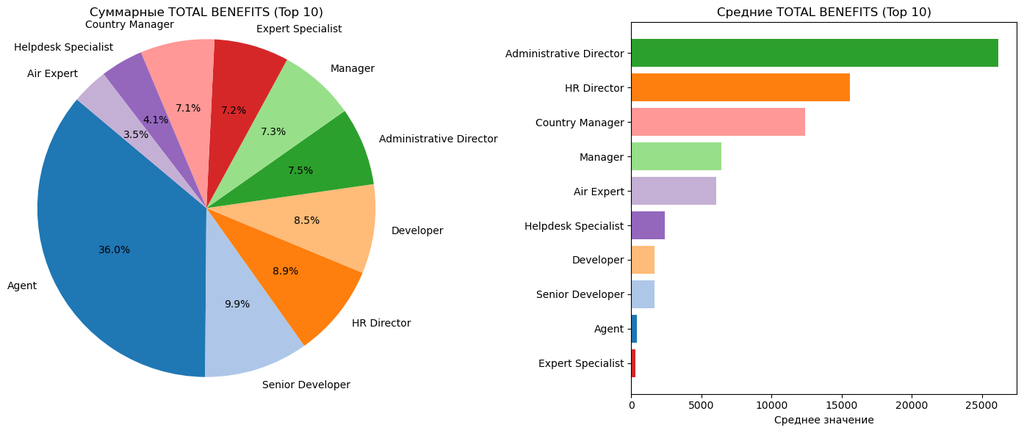

Рассмотрим средние значения бенефитов по должностям в совокупности для обеих стран, чтобы понять, как распределяются выплаты между позициями.

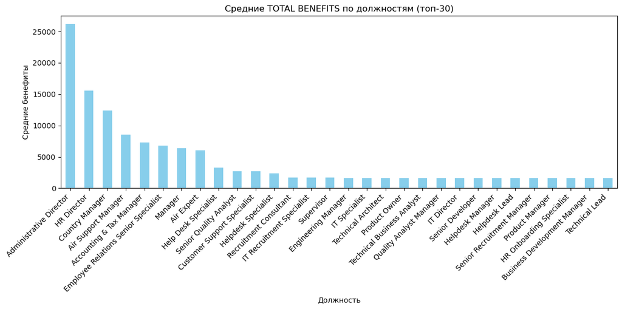

**Из 75 должностей верхние 8 (что составляет ~11% от общего числа) по среднему уровню бенефитов аккумулируют около 60% общей суммы бенефитов**, рассчитанной на основе средних значений на каждую роль. Четыре сотрудника, получающих аномально высокие бенефиты, входят в число этих восьми позиций, что, вероятно, и оказывает значительное влияние на общую долю.

## Executive Summary

### 📌 1. Установить справедливые границы компенсаций по ролям, а не по странам

Графики показывают, что компания выплачивает разные суммы бенефитов за одну и ту же должность в зависимости от страны. Вместо того чтобы ориентироваться только на локацию, стоит установить глобальные компенсационные рамки для каждой должности, с корректировкой под экономическую ситуацию через индексы покупательной способности — например, Purchasing Power Index (Numbeo) или World Bank PLI.

Это важно для:

🤝 Справедливости между сотрудниками  
🚀 Мотивации и удержания персонала  
🧩 Прозрачности и предсказуемости HR-политики

В условиях роста удалённой занятости и глобального найма опора только на "местные ставки" теряет актуальность.

### 📌 2. Проверить обоснованность концентрации бенефитов в ограниченном числе позиций

Из 75 должностей верхние 8 (что составляет ~11% от общего числа) по среднему уровню бенефитов аккумулируют около 60% общей суммы бенефитов, рассчитанной на основе средних значений на каждую роль. Это может быть связано с иерархической структурой компании. Кроме того, четыре сотрудника с аномально высокими значениями бенефитов существенно влияют на статистику, однако такая концентрация в топ-8 позициях требует дополнительной проверки на предмет:

📊 Соответствия роли уровню затрат  
🧾 Справедливости и рыночной конкурентоспособности компенсаций

Рекомендуется провести дополнительный аудит: проанализировать вклад этих позиций в бизнес и сравнить уровень компенсаций с рыночными аналогами, используя публичные источники, такие как Glassdoor, PayScale, или отчёты Mercer.

### 📌 3. Оценить влияние бенефитов на удержание сотрудников

Рекомендуется проанализировать, насколько бенефиты влияют на текучесть персонала. Сравнение уровней бенефитов с динамикой удержания может помочь оценить эффективность пакета льгот как инструмента удержания.

### 📌 4. Постепенное выравнивание компенсационной политики

Следует выработать стратегию постепенного выравнивания подходов к бенефитам:

📈 В странах с низкими выплатами — планомерное повышение  
📉 В странах с завышенными расходами — оптимизация без потери привлекательности

Рекомендуется начать с топ-10 позиций по объёму бенефитов, так как именно там:

1. возможны наибольшие дисбалансы (недополучение или переплаты),
2. лежит основная часть затрат.